# R Notebook

Title: Sampling on the Migration Route: Genetic Structure and Population Assignment of Roseate Terns on the East Atlantic Flyway Date: 2025/10/15

R Environment, v.4.4.0

Read in packages and scripts for analysis

```r
#Read/Write and Manipulate data
library('dplyr')
library('stringr')
library('readr')
library('tidyr')
library('gridExtra')
library('reshape2')
library('magrittr')
#library('pbapply')

#Visualization
library("ggplot2") #v.3.3.1
library("gridExtra") #v.2.3
library('khroma')
library('ggpubr')

#Analysis
library("adegenet") #v.2.1.3
library("pegas") #0.13
library("poppr") #2.8.6
library("hierfstat") #0.4.22
library('boot') #v.1.3.24

#Running in parallel
library('parallel')
library("doParallel")
library("foreach")

source('genind2structure.R')
bootstrap_mean_ci <- function(x, conf.level = 0.95, R = 2000) {
  x <- x[!is.na(x)]

  mean_stat <- function(data, indices) mean(data[indices])

  boot_obj <- boot(x, statistic = mean_stat, R = R)

  ci <- boot.ci(boot_obj, conf = conf.level, type = "perc")

  m <- mean(x)
  lower <- ci$percent[4]
  upper <- ci$percent[5]

  sprintf("%.2f (%.2f-%.2f)", m, lower, upper)
}
```

Read in data files and link lab_id with field_information

```r
#lab_id for genotyped birds
lab_id <- read_csv("data/lab_id_cdgenomics.csv")

#complete field information
complete_info <- read_csv("data/field_info_v2.csv")

#join field information with lab_id
linked_in <- left_join(lab_id, complete_info, by='lab_id') %>%
  dplyr::select(c(lab_id,
                  colony_inferred,
                  year,
                  location,
                  country,
                  hy_ad))

#genotypes
genind_msat = read.genalex("data/msat_cdgenomics_v2.csv", genclone = FALSE)
```

Determine how many birds were genotyped from different years & inferred colony-of-origin (see ms)

```r
#survey the grouping variables
table(linked_in$country, linked_in$year)
```

```
     2021 2022 2023
  SN   55  152   33
  US    0    0   25
```

```r
table(linked_in$colony_inferred, linked_in$year)
```

```
          2021 2022 2023
  AZ         3    4    0
  BR         1    1    0
  COQ        2    0    0
  LIL        3   15    2
  NH         0    0   25
  ROC       11   50   20
  unknown   35   82   11
```

```r
#known age vs. unknown age
table(linked_in$hy_ad, linked_in$colony_inferred)
```

```
     AZ BR COQ LIL NH ROC unknown
  AD  1  0   0   0  0   0       3
  HY  1  1   2  18  0  74       0
```

Add population labels for different grouping arrangements

```r
linked_in <- linked_in %>%
  mutate(
    CIxY = paste0(linked_in$colony_inferred, "_", linked_in$year),
    CxY = paste0(linked_in$country, "_", linked_in$year),
    LxY = paste0(linked_in$location, "_", linked_in$year)
  )
```

Output divstats based on various grouping variables:

Group samples by sampling location x Year: La Somone vs. La Barbarie

```r
all(indNames(genind_msat) == linked_in$lab_id) #naming is consistent
```

```
[1] TRUE
```

```r
pop(genind_msat) <- linked_in$LxY[match(indNames(genind_msat), linked_in$lab_id)]
```

Test for deviations from HWE

```r
# Chi-squared test: p-value
HWE.test <- data.frame(sapply(seppop(genind_msat),
                              function(ls) pegas::hw.test(ls, B=1000)[,4])) # [,4] = Monte-Carlo P-values
HWE.test.ext <- t(data.matrix(HWE.test))
{cat("MC Exact P Values:", "\n")
round(HWE.test.ext,5)}

# Flatten to a vector
pvals_all <- as.vector(HWE.test.ext)
# Apply BY adjustment
pvals_by <- p.adjust(pvals_all, method = "BY")
# Reshape to original dimensions (same order)
HWE.test.ext <- matrix(pvals_by, nrow = nrow(HWE.test.ext), ncol = ncol(HWE.test.ext),
                          dimnames = dimnames(HWE.test.ext))
{cat("MC Exact P Values:", "\n")
round(HWE.test.ext,3)}

#For each locus, what proportion of pops is each locus out of HWE?

alpha=0.05
sum(HWE.test.ext<0.05)/length(HWE.test.ext) #what % of tests yielded significant HWE deviation?
```

Significant deviations from HWE were detected at Calbo1 [locus 11], so it was initially removed from subsequent analyses of genetic diversity & pairwise Fst. However, since exploratory analyses revealed that multiple sites contain private alleles at Calbo1, Fst values were unaffected by inclusion/exclusion of Calbo1, and since DAPC is robust to deviations from HWE, we used the full datast (including Calbo1) to assess all informative alleles retained.

Genetic diversity based on 14 microsatellite loci across years & sampling sites in Senegal

| population | n | p_a | Ar |
| --- | --- | --- | --- |
| La langue de Barbarie_2022 | 123 | 5 | 3.13 (2.30-4.13) |
| La Somone_2022 | 29 | 0 | 3.13 (2.31-4.06) |
| La Somone_2021 | 55 | 1 | 3.17 (2.28-4.19) |
| La langue de Barbarie_2023 | 10 | 0 | 2.98 (2.16-3.90) |
| La Somone_2023 | 23 | 0 | 3.21 (2.31-4.28) |
| Seavey Island_2023 | 25 | 6 | 3.11 (2.20-4.18) |

Group samples based on inferred colony of origin (See ms for description) and calculate genetic diversity (14 microsatellite loci)

```r
Fst_msat
```

```
           NH    AZ   LIL   ROC    BR   COQ unknown
NH         NA 0.093 0.113 0.099 0.159 0.066   0.100
AZ      0.093    NA 0.046 0.039 0.056 0.104   0.000
LIL     0.113 0.046    NA 0.004 0.004 0.099   0.029
ROC     0.099 0.039 0.004    NA 0.027 0.059   0.021
BR      0.159 0.056 0.004 0.027    NA 0.069   0.058
COQ     0.066 0.104 0.099 0.059 0.069    NA   0.116
unknown 0.100 0.000 0.029 0.021 0.058 0.116      NA
```

```r
# Verify the order
pop(reordered_genind)
```

```
  [1] NWA     NWA     NWA     NWA     NWA     NWA     NWA     NWA     NWA     NWA     NWA     NWA     NWA
 [14] NWA     NWA     NWA     NWA     NWA     NWA     NWA     NWA     NWA     NWA     NWA     NWA     AZ
 [27] AZ      AZ      AZ      AZ      AZ      AZ      NWE     NWE     NWE     NWE     NWE     NWE     NWE
 [40] NWE     NWE     NWE     NWE     NWE     NWE     NWE     NWE     NWE     NWE     NWE     NWE     NWE
 [53] NWE     NWE     NWE     NWE     NWE     NWE     NWE     NWE     NWE     NWE     NWE     NWE     NWE
 [66] NWE     NWE     NWE     NWE     NWE     NWE     NWE     NWE     NWE     NWE     NWE     NWE     NWE
 [79] NWE     NWE     NWE     NWE     NWE     NWE     NWE     NWE     NWE     NWE     NWE     NWE     NWE
 [92] NWE     NWE     NWE     NWE     NWE     NWE     NWE     NWE     NWE     NWE     NWE     NWE     NWE
[105] NWE     NWE     NWE     NWE     NWE     NWE     NWE     NWE     NWE     NWE     NWE     NWE     NWE
[118] NWE     NWE     NWE     NWE     NWE     NWE     NWE     NWE     NWE     NWE     NWE     NWE     NWE
[131] NWE     NWE     NWE     NWE     NWE     NWE     NWE     unknown unknown unknown unknown unknown unknown
[144] unknown unknown unknown unknown unknown unknown unknown unknown unknown unknown unknown unknown unknown
[157] unknown unknown unknown unknown unknown unknown unknown unknown unknown unknown unknown unknown unknown
[170] unknown unknown unknown unknown unknown unknown unknown unknown unknown unknown unknown unknown unknown
[183] unknown unknown unknown unknown unknown unknown unknown unknown unknown unknown unknown unknown unknown
[196] unknown unknown unknown unknown unknown unknown unknown unknown unknown unknown unknown unknown unknown
[209] unknown unknown unknown unknown unknown unknown unknown unknown unknown unknown unknown unknown unknown
[222] unknown unknown unknown unknown unknown unknown unknown unknown unknown unknown unknown unknown unknown
[235] unknown unknown unknown unknown unknown unknown unknown unknown unknown unknown unknown unknown unknown
[248] unknown unknown unknown unknown unknown unknown unknown unknown unknown unknown unknown unknown unknown
[261] unknown unknown unknown unknown unknown
Levels: NWA AZ NWE unknown
```

Test for deviations from HWE

```r
# Chi-squared test: p-value
HWE.test <- data.frame(sapply(seppop(genind_msat),
                              function(ls) pegas::hw.test(ls, B=1000)[,4])) # [,4] = Monte-Carlo P-values
# Chi-squared test: p-value
HWE.test <- data.frame(sapply(seppop(genind_msat),
                              function(ls) pegas::hw.test(ls, B=1000)[,4])) # [,4] = Monte-Carlo P-values
HWE.test.ext <- t(data.matrix(HWE.test))
{cat("MC Exact P Values:", "\n")
round(HWE.test.ext,5)}
```

```
MC Exact P Values:
        MsSh18 MsSh23 AAC20 AAT20 RBG27 RBG29   K16 AAT27   LZ2 RBG18 Calbo1 Calbo2 Calbo5 Calbo35 Calbo40
NWA      0.816  1.000 1.000 0.521 1.000     1 0.325 1.000 0.023 0.724  0.000  0.211  0.640   0.253   0.952
AZ       1.000  1.000 1.000 1.000 1.000     1 1.000 1.000 1.000 0.774  0.013  1.000  1.000   0.166   0.315
NWE      0.716  0.579 0.389 1.000 0.001     1 0.004 0.788 0.007 0.740  0.000  0.497  0.022   0.706   0.908
unknown  0.100  0.209 1.000 1.000 0.112     1 0.002 0.584 0.010 0.091  0.000  0.330  0.131   0.289   0.323
```

```r
# Flatten to a vector
pvals_all <- as.vector(HWE.test.ext)
# Apply BY adjustment
pvals_by <- p.adjust(pvals_all, method = "BY")
# Reshape to original dimensions (same order)
HWE.test.ext <- matrix(pvals_by, nrow = nrow(HWE.test.ext), ncol = ncol(HWE.test.ext),
                          dimnames = dimnames(HWE.test.ext))
{cat("MC Exact P Values:", "\n")
round(HWE.test.ext,3)}
```

```
MC Exact P Values:
        MsSh18 MsSh23 AAC20 AAT20 RBG27 RBG29   K16 AAT27   LZ2 RBG18 Calbo1 Calbo2 Calbo5 Calbo35 Calbo40
NWA          1      1     1     1  1.00     1 1.000     1 0.587     1  0.000      1  1.000       1       1
AZ           1      1     1     1  1.00     1 1.000     1 1.000     1  0.406      1  1.000       1       1
NWE          1      1     1     1  0.07     1 0.187     1 0.281     1  0.000      1  0.587       1       1
unknown      1      1     1     1  1.00     1 0.112     1 0.351     1  0.000      1  1.000       1       1
```

```r
#What proportion of tests yielded significant deviation from HWE?
alpha=0.05
sum(HWE.test.ext<0.05)/length(HWE.test.ext)
```

```
[1] 0.05
```

Genetic diversity based on 14 microsatellite loci across inferred metapopulation of origin: Northwest Atlantic (NWA), Azores (AZ), Northwest Europe (NWE), and unknown (unknown)

```r
toRemove=which(locNames(genind_msat) == "Calbo1")
genind_msat_14 <- genind_msat[loc=-toRemove]

#Calculate diversity stats
res.df = data.frame(n = summary(genind_msat_14$pop),
                    population = popNames(genind_msat_14),
                    p_a = private_alleles(genind_msat_14) %>% apply(1, sum),
                    Ar = allelic.richness(genind2hierfstat(genind_msat_14))$Ar %>% apply(2, bootstrap_mean_ci),
                    row.names = NULL) %>%
  relocate(n, .after = population)

#calculate basic divstats using hierfstat
basic_msat = basic.stats(genind_msat_14, diploid = TRUE)

res.df = res.df %>%
  mutate(
    Ho = basic_msat$Ho %>% apply(MARGIN = 2, FUN = mean, na.rm = TRUE) %>% round(2),
    He = basic_msat$Hs %>% apply(MARGIN = 2, FUN = mean, na.rm = TRUE) %>% round(2),
    F = basic_msat$Fis %>% apply(2, bootstrap_mean_ci)
  )


#calculate fstats in hierfstat
hf_msat = genind2hierfstat(genind_msat_14,pop=pop(genind_msat_14))

#pairwise Fst by W-C method
fst_msat = pairwise.WCfst(hf_msat) %>% round(digits = 3)

#bootstrap CIs for pairwise Fst
fst_ci = boot.ppfst(dat=hf_msat,nboot=5000,quant=c(0.025, 0.975),diploid=TRUE)
fst_ci$ll = round(fst_ci$ll,2)
fst_ci$ul = round(fst_ci$ul,2)
fis_ci = boot.ppfis(dat=hf_msat,nboot=5000,quant=c(0.025, 0.975), diploid=TRUE)
fis_ci$fis.ci = round(fis_ci$fis.ci,5)
```

Export genind object for STRUCTURE analysis & prepare for DAPC

```r
table(pop(x))
```

```
AZ
 7
```

Perform DAPC on inferred-origin individuals with the full dataset to identify how well sites can be discriminated from each other by their genotypes (See MS)

```r
table(True = pop(x), Predicted = pred$assign)
```

```
     Predicted
True  NWA AZ NWE
  NWA  22  1   2
  AZ    1  3   3
  NWE   4  4  97
```

Transform coordinates to match geographical arrangement and plot in ggplot2 framework

```r
table(True = pop(x), Predicted = pred$assign)
```

[output not shown]

Rebuild the DAPC model based on all “known-origin” individuals & leverage its loadings to predict the metapopulation origin of “unknown” birds sampled in Senegal (without resighting or banding data)

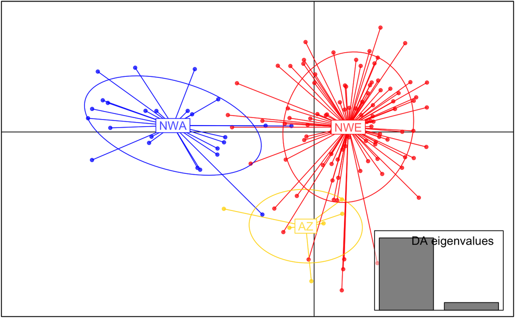

Overlay DAPC-predicted unknowns onto previously generated model

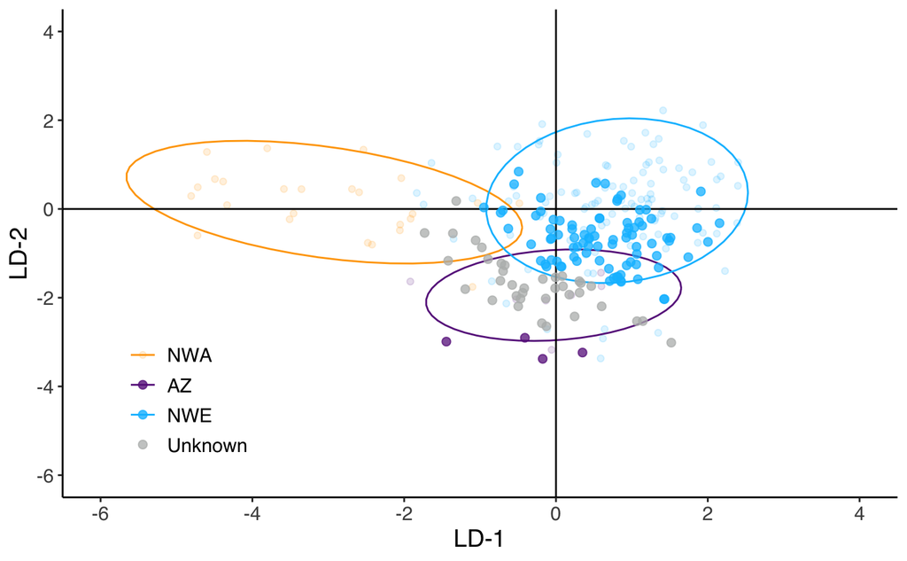

To account for the effects of uneven sampling of known-origin groups (i.e., NWE > 100) on the pop. assignment of unknowns, populations were subsampled prior to dapc() and predict.dapc(). To observe the stability of assignment rates across random subsamples, the following were iterated #s of times across subsamples.

Relevant functions

Iterate DAPC across random subsamples & store results from each iteration. Output results from run.

|  | mean | median | lower_95 | upper_95 |
| --- | --- | --- | --- | --- |
| NWA | 0.8 | 1.0 | 0.000 | 2.000 |
| AZ | 21.5 | 22.0 | 9.225 | 41.850 |
| NWE | 40.4 | 39.5 | 25.450 | 59.200 |
| Unknown | 65.3 | 66.5 | 53.450 | 75.775 |

Generate a representative dataset of assigning unknowns (based on the subsampled model) to use for plotting

```r
table(example_output$dapc_final$grp)
```

```
NWE NWA  AZ
 25  25   7
```

Plot DAPC models Full: (A) Known vs. (B) Known+Unknown Subsampled: (C) Known vs. (D) Known+Unknown

Full model:

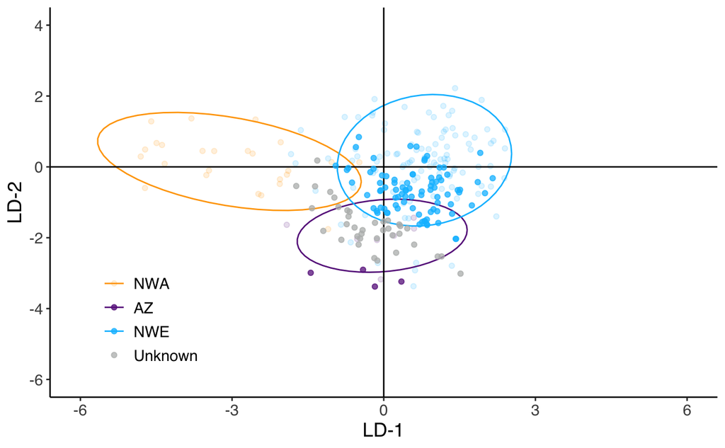

Subsampled Model

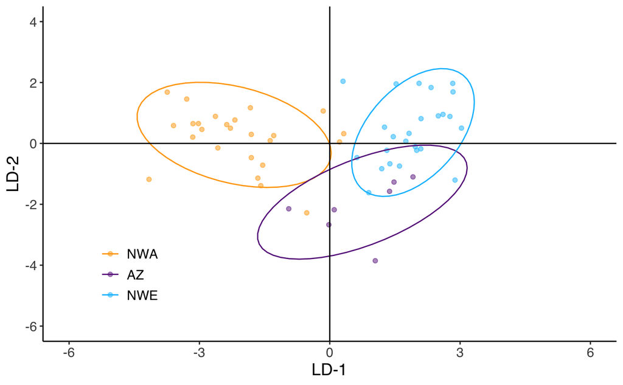

Build Figure 3

```r
dapc_all_combined = ggarrange(p_known_all, p_pred_all,
                               p_known_subset, p_pred_subset,
                               ncol=2, nrow=2, labels = c("A", "B", "C", "D"),
                               legend = "top", common.legend = TRUE, font.label = list(size = 16))
dapc_all_combined
```

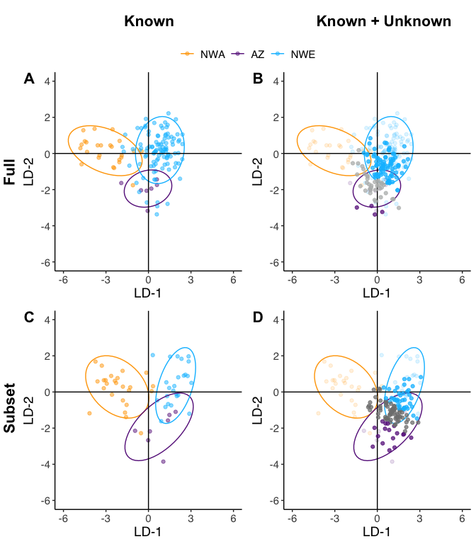

Update original genind_msat with representative example from subsampled dataset; adjust for assignments based on full- vs. subset- model

```r
#pull out names of AZ-predicted origin birds from this example_output
pred_azores_birds = example_output$pred.df$individual[example_output$pred.df$population == "AZ"]
pred_nwe_birds = example_output$pred.df$individual[example_output$pred.df$population == "NWE"]
pred_nwa_birds = example_output$pred.df$individual[example_output$pred.df$population == "NWA"]

genind_msat@pop[which(rownames(genind_msat@tab) %in% pred_azores_birds)] = "AZ"
genind_msat@pop[which(rownames(genind_msat@tab) %in% pred_nwe_birds)] = "NWE"


linked_in$colony_inferred[which(linked_in$lab_id %in% pred_azores_birds)] = 'AZ'
linked_in$colony_inferred[which(linked_in$lab_id %in% pred_nwe_birds)] = 'NWE'

table(linked_in$colony_inferred, linked_in$year)
```

```
          2021 2022 2023
  AZ         9   14    1
  NWA        0    0   25
  NWE       29   86   30
  unknown   17   52    2
```

Visualize “informativeness” of loci in panel based on Global Fst & DAPC loadings

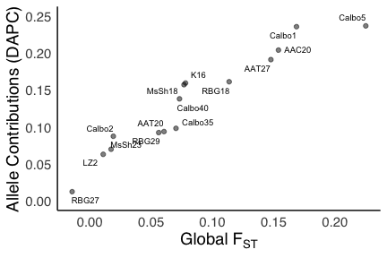